# Biostatistical Computing, PHC 6068

bootsrap and permutation test

Zhiguang Huo (Caleb)

Wednesday November 6, 2017

# Outline

- bootstrap
  - bootstrap variance, confidence interval
  - non-parametric bootstrap, parametric bootstrap
- permutation test
  - size
  - power

# Bootstrap

- Given $X_1, \ldots, X_n$ samples from a distribution, how to estimate the mean of this distribution?
  - Use $\frac{1}{n} \sum_{i=1}^n X_i$ and weak law of large number.
    $$\frac{1}{n} \sum_{i=1}^n X_i \rightarrow E(X_i)$$
- Given $X_1, \ldots, X_n$ samples from a distribution, how to estimate other parameters (Variance, mean squared)? - Similarly use weak law of large number.
- How to get the standard error of that estimator? How to get a confidence interval?
  - Bootstrap
- Although the Bootstrap method is nonparametric, it can be used for inference about parameters in both parametric and nonparametric models.

# Bootstrap variance- Aim

- Suppose $X_1, \ldots, X_n \sim F$ where $F$ is a distribution.
- Let $T_n = g(X_1, \ldots, X_n)$ be a statistic, where $T_n$ is a function of the data.
- What is the variance of $T_n$, $V_F(T_n)$?

# A concrete example

- Suppose $X_1, \ldots, X_n \sim N(\mu,\sigma^2)$ where $N(\mu,\sigma^2)$ is normal distribution.
- Let $T_n = \frac{1}{n} \sum_{i=1}^nX_i$ be a statistic, where $T_n$ is mean of $X_1, \ldots, X_n$.
- What is the variance of $T_n$? By weak law of large number,

$$V_F (T_n) = \sigma^2 / n$$

- How to get an estimate of $V_F (T_n) = \sigma^2 / n$?
  $$\hat{V}_F (T_n) = \hat{\sigma}^2 / n$$

$$\hat{\sigma}^2 = \frac{1}{n - 1}\sum_{i=1}^n (X_i - \bar{X})^2$$

# A example about median

- Suppose $X_1, \ldots, X_n \sim N(\mu,\sigma^2)$ where $N(\mu,\sigma^2)$ is normal distribution.
  - $X_1, \ldots, X_n$ are known and the distribution parameters are unknown.
- Let $T_n = median_{i=1}^n(X_i)$ be a statistic, where $T_n$ is median of $X_1, \ldots, X_n$.
- What is the variance of $T_n$?

Assume $N(\mu,\sigma^2)$ is known

- We can use Monte Carlo simulation method to estimate the variance of $T_n$.

# A example about median, Monte Carlo method

- For $b = 1, \ldots, B$
  - draw $X^{b}_1, \ldots, X^{b}_n \sim N(\mu,\sigma^2)$
  - Compute $T^{(b)}_n = median_{i=1}^n(X^{b}_i)$
- $\bar{T}_n = \frac{1}{B} \sum_{b=1}^B T^{(b)}_n$
- $\hat{V}_F (T_n) = \frac{1}{B - 1} \sum_{b=1}^B \{T^{(b)}_n - \bar{T}_n \}^2$
- By law of large number, $\hat{V}_F (T_n) \rightarrow Var(T_n)$

```r
mu <- 1
sigma <- 1
n <- 100
B <- 1000
Ts <- numeric(B)

for(b in 1:B){
  set.seed(b)
  ax <- rnorm(n, mu, sigma)
  Ts[b] <- median(ax)
}

varTest <- var(Ts)
print(varTest)
```

```
## [1] 0.014573
```

- What if we don’t know $N(\mu,\sigma^2)$?

# Notations

- $F = P(X \le x)$ is a distribution function.
- We can estimate $F$ with the **empirical distribution function** $\hat{F}_n$, the cdf that puts mass $1/n$ at each data point $X_i$.
  $$\hat{F}_n (x) = \frac{1}{n} \sum_{i = 1}^n I(X_i \le x)$$
  where
  $$\begin{equation}
  I(X_i \le x) =
  \begin{cases}
  1, & \text{if}\ X_i \le x \\
  0, & \text{if}\ X_i > x
  \end{cases}
  \end{equation}$$

# Empirical process

- Glivenko-Cantelli Theorem
  $$\sup_x | \hat{F}_n(x) - F(x)| \rightarrow 0$$
- Dvoretzky-Kiefer-Wolfowitz inequality, for any $\varepsilon > 0$
  $$P(\sup_x | \hat{F}_n(x) - F(x)| > \varepsilon) \le 2\exp(-2n\varepsilon^2)$$

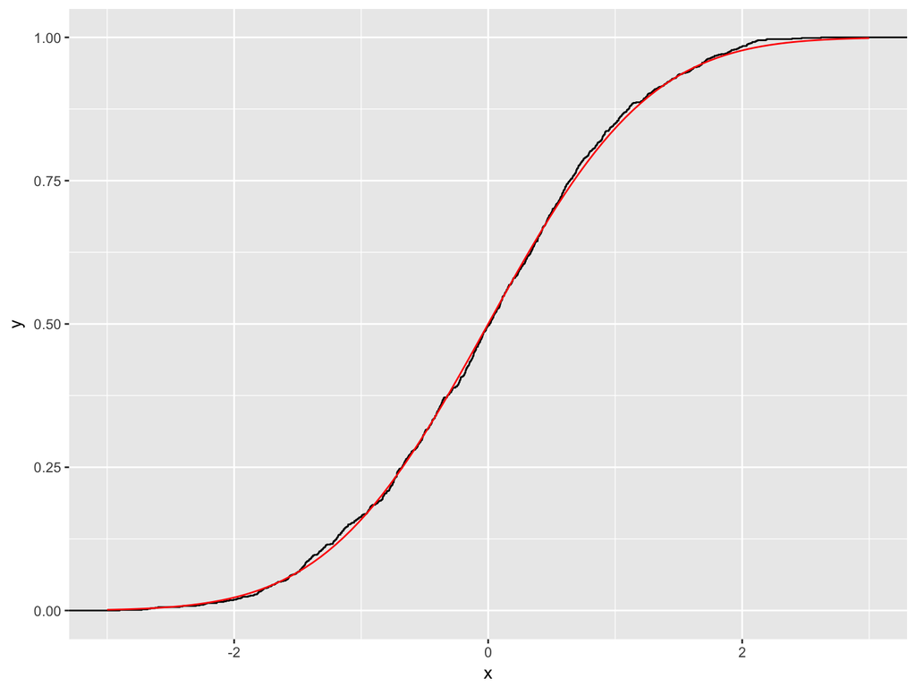

```r
library(ggplot2)
n <- 1000
df <- data.frame(x = c(rnorm(n, 0, 1)))
base <- ggplot(df, aes(x)) + stat_ecdf()
base + stat_function(fun = pnorm, colour = "red") + xlim(c(-3,3))
```

# A example about median, Bootstrap method

- For $b = 1, \ldots, B$
  - draw $X^{b}_1, \ldots, X^{b}_n \sim$ N(mu,sigma^2) $F_n$
  - Compute $T^{(b)}_n = median_{i=1}^n(X^{b}_i)$
- $\bar{T}_n = \frac{1}{B} \sum_{b=1}^B T^{(b)}_n$
- $\hat{V}_F (T_n) = \frac{1}{B} \sum_{b=1}^B \{T^{(b)}_n - \bar{T}_n \}^2$

How to sample from the empirical distribution?

- Drawing $X_1^*, \ldots, X_n^*$ from $F_n$ is equivalent to draw $n$ observations, with replacement from the original data $\{X_1, \ldots, X_n\}$.
- Therefore, bootstrap sampling is also described as resampling data.

# A example about median, Bootstrap method

```r
mu <- 1
sigma <- 1
n <- 100
set.seed(32611)
X <- rnorm(n, mu, sigma)
B <- 1000
Ts <- numeric(B)

for(b in 1:B){
  set.seed(b)
  ax <- sample(X, b, replace = T)
  Ts[b] <- median(ax)
}

varTest <- var(Ts)
print(varTest)
```

[output not shown]

# Bootstrap Variance Estimator

1. Draw a bootstrap sample $X_1^*, \ldots, X_n^* \sim F_n$. Compute $\hat{\theta^*}_n = g(X_1^*, \ldots, X_n^*)$.
2. Repeat the previous step $B$ times, yielding estimators $\hat{\theta^*}_n^{(1)}, \ldots, \hat{\theta^*}_n^{(B)}$.
3. Compute
   $$\hat{var}_{F_n}(\hat{\theta}_n) = \frac{1}{B}\sum_{b=1}^B (\hat{\theta^*}_n^{(b)} - \bar{\theta})^2,$$
   where $\bar{\theta} = \frac{1}{B}\sum_{b=1}^B \hat{\theta^*}_n^{(b)}$
4. Output $\hat{var}_{F_n}(\hat{\theta}_n)$ as the bootstrap variance of $\hat{\theta}_n$.

# Why Bootstrap Variance works?

Notation:

- $p$ is the probability mass function if $F$ is discrete and probability density function if $F$ is continuous.
  $$\begin{equation}
  \int g(x) dF(x)=
  \begin{cases}
  \sum_j g(x_j) p(x_j), & \text{if}\ F\ \text{is discrete} \\
  \int g(x)p(x)dx, & \text{if}\ F\ \text{is continuous}
  \end{cases}
  \end{equation}$$
- $\hat{\theta}_n = g(X_1, \ldots, X_n)$
- $mean_F(\hat{\theta}_n) = \int g(X_1, \ldots, X_n) dF$
- $var_F(\hat{\theta}_n) = \int (g(X_1, \ldots, X_n) - mean_F(\hat{\theta}_n))^2 dF$

Since in general, we don’t know distribution $F$, we will calculate using the empirical CDF $F_n$.

- $var_{F_n}(\hat{\theta}_n) = \int (g(X_1, \ldots, X_n) - mean_{F_n}(\hat{\theta}_n))^2 dF_n$
- Finally we used bootstrap variance $\hat{var}_{F_n}(\hat{\theta}_n)$ to estimate $var_{F_n}(\hat{\theta}_n)$.

To summarize:

- Estimation error: $var_F(\hat{\theta}_n) - var_{F_n}(\hat{\theta}_n) = O_p(1/\sqrt{n})$
- Simulation error: $var_{F_n}(\hat{\theta}_n) - \hat{var}_{F_n}(\hat{\theta}_n) = O_p(1/\sqrt{B})$

# The parametric Bootstrap (an example for median)

- calculate $\hat{\mu} = \arg\min L(\mu;X_1^n)$, $\sigma$ is known.
- For $b = 1, \ldots, B$
  - draw $X^{b}_1, \ldots, X^{b}_n \sim N(\hat{\mu},\sigma^2)$ (kind of parametric empirical distribution $\hat{F}$)
  - Compute $\hat{\theta}^{(b)}_n = median_{i=1}^n(X^{b}_i)$
- $\bar{\hat{\theta}}_n = \frac{1}{B} \sum_{b=1}^B \hat{\theta}^{(b)}_n$
- $\hat{V}_F (T_n) = \frac{1}{B} \sum_{b=1}^B \{\hat{\theta}^{(b)}_n - \bar{\hat{\theta}}_n \}^2$

```r
mu <- 1
sigma <- 1
n <- 100
set.seed(32611)
X <- rnorm(n, mu, sigma)
muhat <- mean(X)
B <- 1000
Ts <- numeric(B)

for(b in 1:B){
  set.seed(b)
  ax <- rnorm(n,muhat,sigma)
  Ts[b] <- median(ax)
}

varTest <- var(Ts)
print(varTest)
```

```
## [1] 0.014573
```

# Comparison study using delta method, non-parametric Bootstrap and parametric Bootstrap

- $X_1, \ldots, X_n \sim POI(\lambda)$ ($\lambda = 5$), while we only observe the data $X_1, \ldots, X_n$ and know data is from Poisson.
- $n = 100$
- $T_n = (\frac{1}{n}\sum_{i=1}^nX_i)^2$
- What is the variance of $T_n$?

# Delta method

- $\hat{\lambda} = \bar{X}$
- $var(\bar{X}) = \frac{\lambda}{n}$
- $var(T_n) = var(\bar{X}^2) = (2 \lambda)^2 \times var(\bar{X}) = \frac{4\lambda^3}{n}$
- $\hat{var}_F(T_n) = \frac{4\hat{\lambda}^3}{n} = \frac{4\bar{X}^3}{n}$

```r
lambda <- 5
n <- 100
set.seed(32611)
X <- rpois(n, lambda)
var_hat1 <- 4*mean(X)^3/n
print(var_hat1)
```

```
## [1] 4.97006
```

# Bootstrap (non-parametric Bootstrap)

```r
lambda <- 5
n <- 100
set.seed(32611)
X <- rpois(n, lambda)
B <- 1000
TB <- numeric(B)
for(b in 1:B){
  set.seed(b)
  aX <- sample(X,n,replace = T)
  TB[b] <- (mean(aX))^2
}
var_hat2 <- var(TB)
print(var_hat2)
```

```
## [1] 4.389935
```

# Parametric Bootstrap

```r
lambda <- 5
n <- 100
set.seed(32611)
X <- rpois(n, lambda)
lambdaHat <- mean(X)
B <- 1000
TB <- numeric(B)
for(b in 1:B){
  set.seed(b)
  aX <- rpois(n, lambdaHat)
  TB[b] <- (mean(aX))^2
}
var_hat3 <- var(TB)
print(var_hat3)
```

```
## [1] 5.261807
```

# Bootstrap using R package

```r
library(boot)
myMean <- function(data, indices){
  d <- data[indices]
  mean(d)^2
}

## non parametric bootstrap
boot_nonpara <- boot(data=X, statistic = myMean, R = B)
var(boot_nonpara$t)
```

```
##          [,1]
## [1,] 4.208818
```

```r
## parametric bootstrap
genPois <- function(data, lambda){
  rpois(length(data), lambda)
}
boot_para <- boot(data=X, statistic = myMean, R = B, sim="parametric", ran.gen = genPois, mle = mean(X))
var(boot_para$t)
```

```
##          [,1]
## [1,] 5.264366
```

# Bootstrap confidence interval

- Percentiles
- Pivotal Intervals
- Pivotal Intervals (simplified)
- normal approximation

# Bootstrap confidence interval via Percentiles (Empirically performs well, but there is no theoretical guarantee to work)

1. Draw a bootstrap sample $X_1^*, \ldots, X_n^* \sim F_n$. Compute $\hat{\theta^*}_n = g(X_1^*, \ldots, X_n^*)$.
2. Repeat the previous step $B$ times, yielding estimators $\hat{\theta^*}_n^{(1)}, \ldots, \hat{\theta^*}_n^{(B)}$.
3. Rank $\hat{\theta^*}_n^{(1)}, \ldots, \hat{\theta^*}_n^{(B)}$ such that $\hat{\theta^r}_n^{(1)} \le \hat{\theta^r}_n^{(2)} \le \ldots \le \hat{\theta^r}_n^{(B)}$

We can define 95% confidence interval using (if B = 10,000)
$$[\hat{\theta^r}_n^{(250)}, \hat{\theta^r}_n^{(9750)}]$$

# Performance of Bootstrap confidence interval via Percentiles (1)

```r
lambda <- 5
n <- 100
set.seed(32611)
X <- rpois(n, lambda)
B <- 1000
TB <- numeric(B)
for(b in 1:B){
  set.seed(b)
  aX <- sample(X,n,replace = T)
  TB[b] <- (mean(aX))^2
}
quantile(TB, c(0.025, 0.975))
```

```
##    2.5%   97.5%
## 21.0681 29.2681
```

# Performance of Bootstrap confidence interval via Percentiles (2)

- Underlying truth:

$$E(\bar{X}^2) = E(\bar{X})^2 + var(\bar{X}) = \lambda^2 + \lambda/n$$

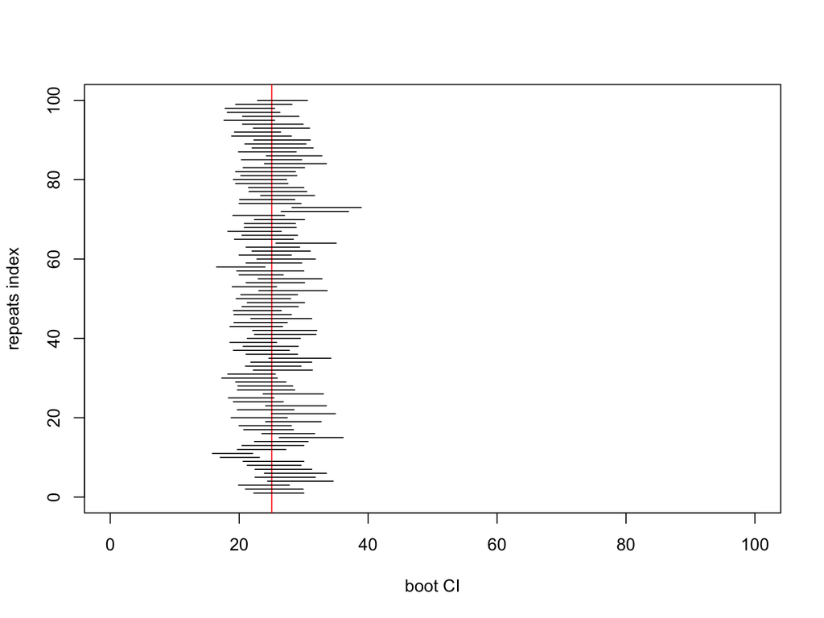

```r
lambda <- 5
n <- 100
truth <- lambda^2 + lambda/n
B <- 1000
Repeats <- 100

counts <- 0

plot(c(0,100),c(0,Repeats), type="n", xlab="boot CI", ylab="repeats index")
abline(v = truth, col=2)

for(r in 1:Repeats){
  set.seed(r)
  X <- rpois(n, lambda)
  TB <- numeric(B)
  for(b in 1:B){
    set.seed(b)
    aX <- sample(X,n,replace = T)
    TB[b] <- (mean(aX))^2
  }
  segments(quantile(TB, c(0.025)), r, quantile(TB, c(0.975)), r)
  if(quantile(TB, c(0.025)) < truth & truth < quantile(TB, c(0.975))){
    counts <- counts + 1
  }
}
```

```r
counts/Repeats
```

```
## [1] 0.93
```

# Performance of Bootstrap confidence interval via Percentiles (3)

- We can also obtain this Percentiles CI by boot package

```r
library(boot)
myMean <- function(data, indices){
  d <- data[indices]
  mean(d)^2
}
boot_nonpara <- boot(data=X, statistic = myMean, R = B)
boot.ci(boot_nonpara, type="perc")
```

```
## BOOTSTRAP CONFIDENCE INTERVAL CALCULATIONS
## Based on 1000 bootstrap replicates
##
## CALL :
## boot.ci(boot.out = boot_nonpara, type = "perc")
##
## Intervals :
## Level     Percentile
## 95%   (22.85, 31.02 )
## Calculations and Intervals on Original Scale
```

```r
?boot.ci
```

# Bootstrap confidence interval via Pivotal Intervals (better accuracy and theoretical guarantee), (There is a improved way to do this later)

1. Draw a bootstrap sample $X_1^*, \ldots, X_n^* \sim F_n$. Compute $\hat{\theta^*}_n = g(X_1^*, \ldots, X_n^*)$.
2. Repeat the previous step $B$ times, yielding
   - estimators $\hat{\theta^*}_n^{(1)}, \ldots, \hat{\theta^*}_n^{(B)}$
   - standard error $\hat{\sigma^*}_n^{(1)}, \ldots, \hat{\sigma^*}_n^{(B)}$
3. Compute
   - $t_b^* = \frac{\hat{\theta^*}_n^{(b)} - \hat{\theta}_n}{\hat{\sigma^*}_n^{(b)}}$
4. Given $t_b^*$ for $b \in \{1, \ldots, B\}$, define the $\alpha$ quantile $q_\alpha$ as
   $$\sum_{b=1}^B I(t_b^* \le q_\alpha)/B = \alpha$$
   $$\begin{align}
   1 - \alpha & = P(q_{\alpha/2} < t_b^* < q_{1 - \alpha/2}) \\
   & \approx P(q_{\alpha/2} < t < q_{1 - \alpha/2}) \\
   & = P(q_{\alpha/2}\hat{\sigma}_B < \hat{\theta}_n - \theta < q_{1 - \alpha/2}\hat{\sigma}_B) \\
   & = P( \hat{\theta}_n - q_{1 - \alpha/2}\hat{\sigma}_B < \theta < \hat{\theta}_n - q_{\alpha/2}\hat{\sigma}_B )
   \end{align}$$

We can define $1 - \alpha$ confidence interval using
$$[\hat{\theta}_n - q_{1 - \alpha/2}\hat{\sigma}_B, \hat{\theta}_n - q_{\alpha/2}\hat{\sigma}_B],$$

Where $\hat{\theta}_n$ is the estimator from the original sample and $\hat{\sigma}_B$ is bootstrap se.

If $\hat{\sigma^*}_n^{(b)}$ is hard to estiamte, we need to use another round of bootstrap to estiamte.

# Performance of Bootstrap confidence interval via Pivotal Intervals (1)

```r
lambda <- 5
n <- 100
set.seed(32611)
X <- rpois(n, lambda)
B <- 1000
TB <- numeric(B)
seB <- numeric(B)
tB <- numeric(B)
lambdaHat <- mean(X)
That <- lambdaHat^2 + lambdaHat/n
for(b in 1:B){
  set.seed(b)
  aX <- sample(X,n,replace = T)
  TB[b] <- (mean(aX))^2
  seB[b] <- sqrt(4*lambdaHat^3/n^2)
  tB[b] <- (TB[b] - That)/seB[b]
}

se_boot <- sd(TB)/sqrt(n)

CI_l <- That - quantile(tB, 0.975) * se_boot
CI_h <- That - quantile(tB, 0.025) * se_boot

print(c(CI_l, CI_h))
```

```
##    97.5%     2.5%
## 20.89173 28.59832
```

# Performance of Bootstrap confidence interval via Pivotal Intervals (2)

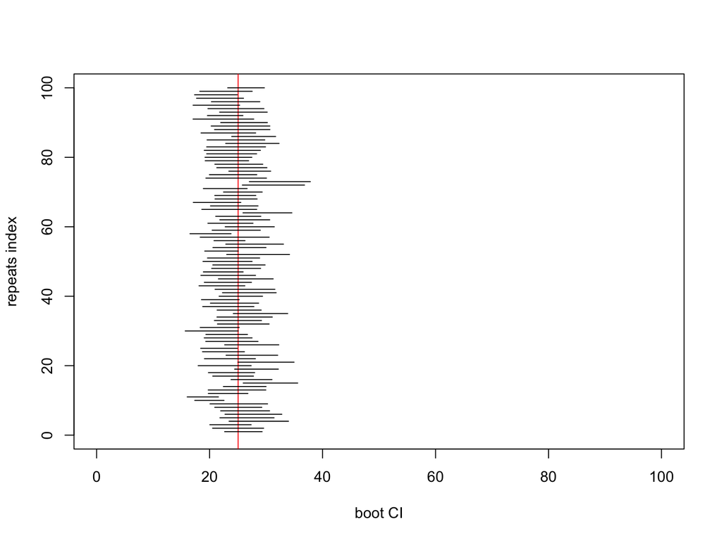

```r
lambda <- 5
n <- 100
truth <- lambda^2 + lambda/n
B <- 1000
Repeats <- 100

counts <- 0

plot(c(0,100),c(0,Repeats), type="n", xlab="boot CI", ylab="repeats index")
abline(v = truth, col=2)

for(r in 1:Repeats){
  set.seed(r)
  X <- rpois(n, lambda)
  TB <- numeric(B)
  seB <- numeric(B)
  tB <- numeric(B)
  lambdaHat <- mean(X)
  That <- lambdaHat^2 + lambdaHat/n
  for(b in 1:B){
    set.seed(b)
    aX <- sample(X,n,replace = T)
    TB[b] <- (mean(aX))^2
    seB[b] <- sqrt(4*lambdaHat^3/n^2)
    tB[b] <- (TB[b] - That)/seB[b]
  }
  se_boot <- sd(TB)/sqrt(n)

  CI_l <- That - quantile(tB, 0.975) * se_boot
  CI_h <- That - quantile(tB, 0.025) * se_boot
  segments(CI_l, r, CI_h, r)
  if(CI_l < truth & truth < CI_h){
    counts <- counts + 1
  }
}
```

```r
counts/Repeats
```

```
## [1] 0.91
```

# Bootstrap confidence interval via Pivotal Intervals - no SE (better accuracy and theoretical guarantee)

1. Draw a bootstrap sample $X_1^*, \ldots, X_n^* \sim F_n$. Compute $\hat{\theta^*}_n = g(X_1^*, \ldots, X_n^*)$.
2. Repeat the previous step $B$ times, yielding
   - estimators $\hat{\theta^*}_n^{(1)}, \ldots, \hat{\theta^*}_n^{(B)}$
3. Compute
   - $t_b^* = \hat{\theta^*}_n^{(b)} - \hat{\theta}_n$
4. Given $t_b^*$ for $b \in \{1, \ldots, B\}$, define the $\alpha$ quantile $q_\alpha$ as
   $$\sum_{b=1}^B I(t_b^* \le q_\alpha)/B = \alpha$$
   $$\begin{align}
   1 - \alpha & = P(q_{\alpha/2} < t_b^* < q_{1 - \alpha/2}) \\
   & \approx P(q_{\alpha/2} < t < q_{1 - \alpha/2}) \\
   & = P(q_{\alpha/2} < \hat{\theta}_n - \theta < q_{1 - \alpha/2}) \\
   & = P( \hat{\theta}_n - q_{1 - \alpha/2} < \theta < \hat{\theta}_n - q_{\alpha/2} )
   \end{align}$$

We can define $1 - \alpha$ confidence interval using
$$[\hat{\theta}_n - q_{1 - \alpha/2}, \hat{\theta}_n - q_{\alpha/2}],$$

Where $\hat{\theta}_n$ is the estimator from the original sample. No $\hat{\sigma}_B$ is required.

# Performance of Bootstrap confidence interval via Pivotal Intervals (no SE)

- Remove SE term.

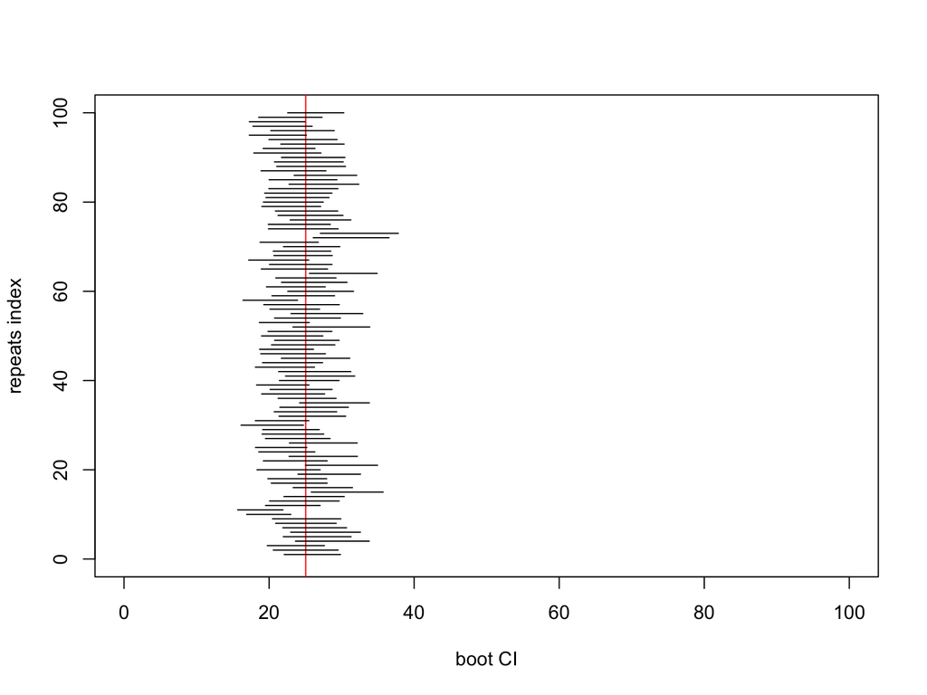

```r
lambda <- 5
n <- 100
truth <- lambda^2 + lambda/n
B <- 1000
Repeats <- 100

counts <- 0

plot(c(0,100),c(0,Repeats), type="n", xlab="boot CI", ylab="repeats index")
abline(v = truth, col=2)

for(r in 1:Repeats){
  set.seed(r)
  X <- rpois(n, lambda)
  TB <- numeric(B)
  seB <- numeric(B)
  tB <- numeric(B)
  lambdaHat <- mean(X)
  That <- lambdaHat^2 + lambdaHat/n
  for(b in 1:B){
    set.seed(b)
    aX <- sample(X,n,replace = T)
    TB[b] <- (mean(aX))^2
    tB[b] <- (TB[b] - That)
  }

  CI_l <- That - quantile(tB, 0.975)
  CI_h <- That - quantile(tB, 0.025)
  segments(CI_l, r, CI_h, r)
  if(CI_l < truth & truth < CI_h){
    counts <- counts + 1
  }
}
```

```r
counts/Repeats
```

```
## [1] 0.91
```

# Normal approximation

$$[\hat{\theta}_n - Z_{1 - \alpha/2}\hat{\sigma}_B, \hat{\theta}_n - Z_{\alpha/2}\hat{\sigma}_B],$$
Where $Z_\alpha = \Phi^{-1}(1-\alpha)$, $\Phi$ is the cdf of standard Normal distribution.

- $Z_{0.025} = -1.96$
- $Z_{0.975} = 1.96$

Where $\hat{\theta}_n$ is the estimator from the original sample and $\hat{\sigma}_B$ is bootstrap se.

# experiment for Normal approximation

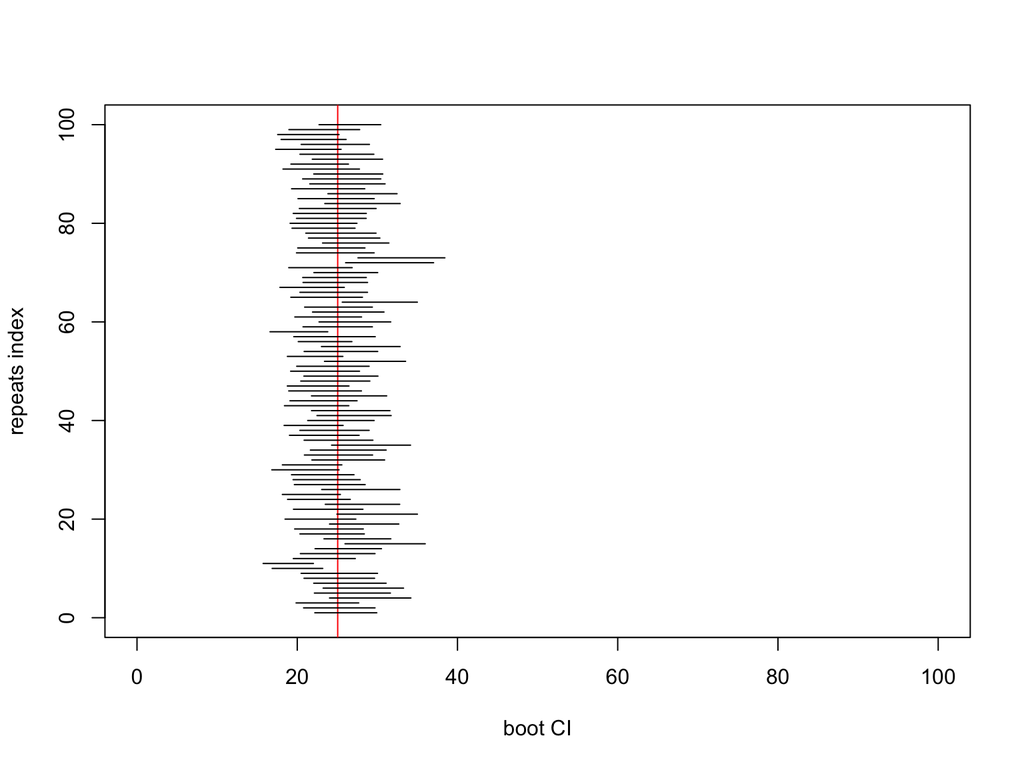

```r
lambda <- 5
n <- 100
truth <- lambda^2 + lambda/n
B <- 1000
Repeats <- 100

counts <- 0

plot(c(0,100),c(0,Repeats), type="n", xlab="boot CI", ylab="repeats index")
abline(v = truth, col=2)

for(r in 1:Repeats){
  set.seed(r)
  X <- rpois(n, lambda)
  lambdaHat <- mean(X)
  That <- lambdaHat^2 + lambdaHat/n
  TB <- numeric(B)
  for(b in 1:B){
    set.seed(b)
    aX <- sample(X,n,replace = T)
    TB[b] <- (mean(aX))^2
  }
  ci_l <- That - 1.96*sd(TB)
  ci_u <- That + 1.96*sd(TB)
  segments(ci_l, r, ci_u, r)
  if(ci_l < truth & truth < ci_u){
    counts <- counts + 1
  }
}
```

```r
counts/Repeats
```

```
## [1] 0.93
```

# Summary Bootstrap confidence interval

| Precedure | Theoritical guarantee | Fast | R package Boot? |
| --- | --- | --- | --- |
| Percentiles | No | Yes | Yes |
| Pivotal Intervals | Yes | No | Yes |
| Pivotal Intervals (simplified, no se) | Yes | Yes | No |
| normal approximation | Yes | Yes | Yes |

# Large scale bootstrap exercise

- For the HAPMAP data Chr1.rdata.
- Calculate the sample contrivance matrix.
- what is the bootstrap variance of the largest eigen value.
- what is the bootstrap confidence interval of the largest eigen value.

# Permutation test

- Distribution free.
- Doesn’t involve any asymptotic approximations.

Problem setting:

- Suppose we have data
  - $X_1, \ldots, X_n \sim F$
  - $Y_1, \ldots, Y_m \sim G$
- We want to test: $H_0: F=G$ versus $H_1: F \ne G$

# Permutation test procedure

- If we want to test if the mean parameter of two distributions are the same.
- Let $Z = (X_1, \ldots, X_n, Y_1, \ldots, Y_m)$.
- Create labels $L = (1,1,\ldots, 1,2,2,\ldots, 2)$ such that there are $n$ copies of 1 and $m$ copies of 2.
- A test statistics can be written as a function of $Z$ and $L$. For example,
  $$T = |\bar{X}_n - \bar{Y}_m|$$
  or

$$T = |
\frac
{\sum_{i = 1}^NZ_i I(L_i=1)}
{\sum_{i = 1}^N I(L_i=1)}
-
\frac
{\sum_{i = 1}^NZ_i I(L_i=2)}
{\sum_{i = 1}^N I(L_i=2)}
|,$$
where $N = n + m$. Therefore the test statistic $T = g(L,Z)$ is a function of $L$ and $Z$.

# Permutation test procedure (2)

- Define
  $$p = \frac{1}{N!}\sum_\pi I(g(L_\pi,Z) \ge g(L,Z)),$$

where $L_\pi$ is a permutation of the labels and the sum is over all permutations.

- Under $H_0$, permuting the labels does not change the distribution.
  - In other word, $g(L,Z)$ has equal chances of having any rank among all permuted values.
  - Under $H_0$, $p \sim Unif(0,1)$
  - If we reject when $p<\alpha$, then we have a level $\alpha$ test

# Permutation test procedure (3)

Sometimes summing over all possible permutations is infeasible. But it suffices to use a random sample of permutation.

Permutation test procedure:

1. Calculate the observed test statistic $T = g(L,Z)$
2. Compute a random permutation of the labels $L_k$ and compute $T^{(k)} = g(L_k,Z)$. Do this $K$ times giving values of $T^{(1)}, \ldots, T^{(K)}$.
3. Compute the p-value as:
   $$\frac{1}{K} \sum_{k=1}^K I(T^{(k)} \ge T )$$

# An illustrating example

- $n = 100$, $m = 100$
- $X_i \sim N(0,1^2)$
- $Y_i \sim N(0,2^2)$

If we observe $X_1, \ldots, X_n$ and $Y_1, \ldots, Y_m$, how can we test if the mean of $X$ and mean of $Y$ have a difference.

```r
n <- 100
m <- 100

set.seed(32611)
x <- rnorm(n,0,1)
y <- rnorm(n,0,2)

adataFrame <- data.frame(data=c(x,y),label=gl(2,n))

T <- with(adataFrame, mean(data[label==1] - data[label==2]))

B <- 1000

TB <- numeric(B)

for(b in 1:B){
  set.seed(b)
  bdataFrame <- adataFrame
  bdataFrame$label <- sample(bdataFrame$labe)
  TB[b] <- with(bdataFrame, mean(data[label==1] - data[label==2]))
}

sum(TB >= T)/B
```

```
## [1] 0.383
```

# Examine the size of the test

```r
n <- 100
m <- 100
R <- 300
B <- 300
alpha <- 0.05

counts <- 0
for(r in 1:R){
  set.seed(r)
  x <- rnorm(n,0,1)
  y <- rnorm(n,0,2)

  adataFrame <- data.frame(data=c(x,y),label=gl(2,n))

  T <- with(adataFrame, mean(data[label==1] - data[label==2]))


  TB <- numeric(B)

  for(b in 1:B){
    set.seed(b*r)
    bdataFrame <- adataFrame
    bdataFrame$label <- sample(bdataFrame$labe)
    TB[b] <- with(bdataFrame, mean(data[label==1] - data[label==2]))
  }

  if(sum(TB >= T)/B > alpha){
    counts <- counts + 1
  }
}
counts/B
```

```
## [1] 0.9366667
```

# Compare power of permutation test and t.test

Consider $H_0: \mu_X = \mu_Y$ versus $H_A: \mu_X > \mu_Y$

- $n = 100$, $m = 100$
- $X_i \sim N(1,3^2)$
- $Y_i \sim N(0,3^2)$

```r
n <- 100
m <- 100
R <- 300
B <- 300
alpha <- 0.05

counts_ttest <- 0
counts_perm <- 0

for(r in 1:R){
  set.seed(r)
  x <- rnorm(n,1,3)
  y <- rnorm(n,0,3)

  if(t.test(x,y,alternative = "greater")$p.val < alpha){
    counts_ttest <- counts_ttest + 1
  }

  adataFrame <- data.frame(data=c(x,y),label=gl(2,n))

  T <- with(adataFrame, mean(data[label==1] - data[label==2]))
  TB <- numeric(B)

  for(b in 1:B){
    set.seed(b*r)
    bdataFrame <- adataFrame
    bdataFrame$label <- sample(bdataFrame$labe)
    TB[b] <- with(bdataFrame, mean(data[label==1] - data[label==2]))
  }

  if(sum(TB >= T)/B < alpha){
    counts_perm <- counts_perm + 1
  }
}
counts_ttest/B
```

```
## [1] 0.7933333
```

```r
counts_perm/B
```

```
## [1] 0.78
```

# When to use permutation test

# Reference

- http://www.stat.cmu.edu/~larry/=stat705/Lecture13.pdf
- http://users.stat.umn.edu/~helwig/notes/bootci-Notes.pdf
- http://www.stat.cmu.edu/~larry/=stat705/Lecture10.pdf

```r
knitr::purl("bootstrap.rmd", output = "bootstrap.R ", documentation = 2)
```

```
##
##
## processing file: bootstrap.rmd
```

[output not shown]

```
## output file: bootstrap.R
```

```
## [1] "bootstrap.R "
```